# Loading and preprocessing the data

## Loading and preprocessing the data

```r
setwd("/Users/Tammy/online_courses/data_science/RepData_PeerAssessment1")
dat<- read.csv(unz("activity.zip","activity.csv"))
dat$date<- as.Date(dat$date)
```

## What is mean total number of steps taken per day?

```
## stat_bin: binwidth defaulted to range/30. Use 'binwidth = x' to adjust this.
```

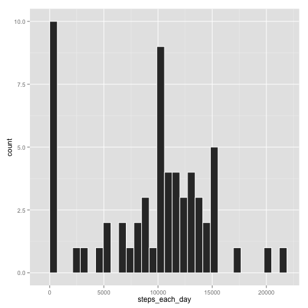

```r
library(dplyr)
library(ggplot2)
dat<- tbl_df(dat)
steps_per_day<- dat %>% group_by(date) %>% summarise(steps_each_day=sum(steps, na.rm=T))
# make a histogram
ggplot(steps_per_day) + geom_histogram(aes(x=steps_each_day), color="white")
```

Calculate and report the mean and median of the total number of steps taken per day

```r
dat %>% group_by(date) %>% summarise(mean_steps=mean(steps, na.rm=T),
                                     median_steps=median(steps, na.rm=T)) %>% print(n=61)
```

```
## Source: local data frame [61 x 3]
##
##          date mean_steps median_steps
## 1  2012-10-01         NA           NA
## 2  2012-10-02  0.4375000            0
## 3  2012-10-03 39.4166667            0
## 4  2012-10-04 42.0694444            0
## 5  2012-10-05 46.1597222            0
## 6  2012-10-06 53.5416667            0
## 7  2012-10-07 38.2465278            0
## 8  2012-10-08        NaN           NA
## 9  2012-10-09 44.4826389            0
## 10 2012-10-10 34.3750000            0
## 11 2012-10-11 35.7777778            0
## 12 2012-10-12 60.3541667            0
```

[output cut: 49 more lines]

## What is the average daily activity pattern?

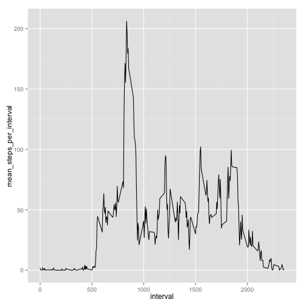

```r
interval_mean_steps<- dat %>% group_by(interval) %>% summarise(mean_steps_per_interval=mean(steps, na.rm=T))
ggplot(interval_mean_steps) + geom_line(aes(x=interval, y=mean_steps_per_interval))
```

Which 5-minute interval, on average across all the days in the dataset, contains the maximum number of steps?

```r
interval_mean_steps %>% arrange(desc(mean_steps_per_interval)) %>% head(n=1)
```

```
## Source: local data frame [1 x 2]
##
##   interval mean_steps_per_interval
## 1      835                206.1698
```

## Imputing missing values

How many NAs in the orignal dataset?(how many rows contain NAs?)

```r
table(complete.cases(dat))
```

```
##
## FALSE  TRUE
##  2304 15264
```

There are total 2304 rows containing NAs.

use the mean of that 5 min interval of all days to impute the missing NAs

```r
dat_no_NA<- dat
for (i in which(is.na(dat$steps))){
        idx<- interval_mean_steps$interval == as.numeric(dat[i,3])
        imputing_value<- as.numeric(interval_mean_steps[idx,2])
        dat_no_NA[i,1]<- imputing_value
}
```

histogram of total number of steps taken each day

```
## stat_bin: binwidth defaulted to range/30. Use 'binwidth = x' to adjust this.
```

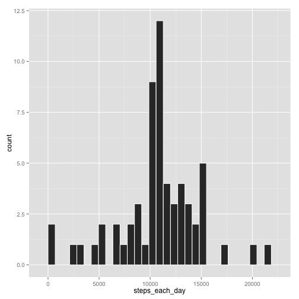

```r
steps_per_day_no_NA<- dat_no_NA %>% group_by(date) %>%
        summarise(steps_each_day=sum(steps, na.rm=T))
ggplot(steps_per_day_no_NA) + geom_histogram(aes(x=steps_each_day), color="white")
```

After imputing missing values, in some of the days, the mean steps are very close to the median steps

```r
dat_no_NA %>% group_by(date) %>% summarise(mean_steps=mean(steps, na.rm=T),
                                     median_steps=median(steps, na.rm=T)) %>% print(n=61)
```

```
## Source: local data frame [61 x 3]
##
##          date mean_steps median_steps
## 1  2012-10-01 37.3825996     34.11321
## 2  2012-10-02  0.4375000      0.00000
## 3  2012-10-03 39.4166667      0.00000
## 4  2012-10-04 42.0694444      0.00000
## 5  2012-10-05 46.1597222      0.00000
## 6  2012-10-06 53.5416667      0.00000
## 7  2012-10-07 38.2465278      0.00000
## 8  2012-10-08 37.3825996     34.11321
## 9  2012-10-09 44.4826389      0.00000
## 10 2012-10-10 34.3750000      0.00000
## 11 2012-10-11 35.7777778      0.00000
## 12 2012-10-12 60.3541667      0.00000
```

[output cut: 49 more lines]

## Are there differences in activity patterns between weekdays and weekends?

add a column containing whether it is a weekday or weekend

```r
dat_weekday_weekend<- dat_no_NA %>%
        mutate(weekday_or_weekend= ifelse(weekdays(date)=="Saturday" |
                                                        weekdays(date) == "Sunday",
                                               "weekend", "weekday"))
dat_weekday_weekend$weekday_or_weekend<- as.factor(dat_weekday_weekend$weekday_or_weekend)
```

calculate the average steps every 5 min interval for weekdays and weekends

```r
weekday_weekend_mean_steps<- dat_weekday_weekend %>% group_by(weekday_or_weekend, interval) %>%
        summarise(mean_steps=mean(steps))
```

plot a line graph for the mean steps of weekdays and weekends respectively.

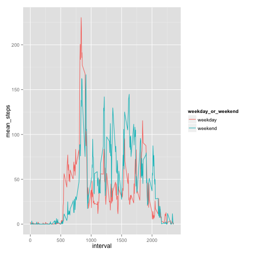

```r
ggplot(weekday_weekend_mean_steps) + geom_line(aes(x=interval, y=mean_steps,
                                                   colour=weekday_or_weekend))
```

or to make two plots in two panels

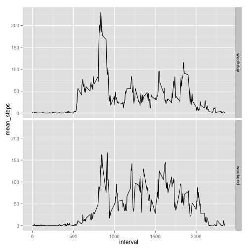

```r
ggplot(weekday_weekend_mean_steps) + geom_line(aes(x=interval, y=mean_steps)) +
        facet_grid(weekday_or_weekend ~ .)
```

### use facet_wrap rather than use facet_grid

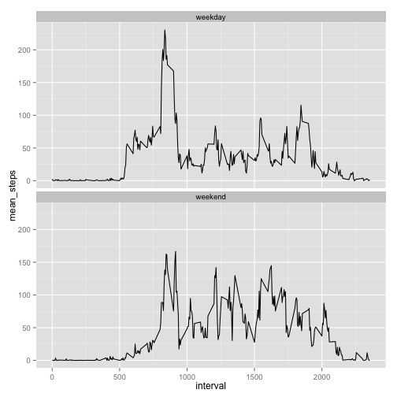

```r
ggplot(weekday_weekend_mean_steps) + geom_line(aes(x=interval, y=mean_steps)) +
        facet_wrap(~weekday_or_weekend, ncol=1)
```

### it looks like this person took more steps over the weekends on average.